# Geography 13

Final

Personal Landing Page

> Your final for this class is to submit your personal website complete with an About Me, GIS projects, and CV page.

##### Due: September 14<sup>th</sup> 11:59 pm (no extension will be possible)

## **About Me Page**:

Describe what you now know, and how you can use those skills in a field of your choice. This should be targeted at someone who doesn’t know you or this class - in this context - consider it a brief, generic cover letter.

Additionally a contact (email) and Github link should be prominently listed

## **Geography 13 page**:

All six labs should be documented and include the following (5 points for each lab):

- A hyperlink to the lab (H1 heading)
- 3-5 bullet points describing what you did and what you learned
- **EXTRA CREDIT**: For labs 2-6, one image from the lab that highlights what you did (2 points for each lab, 10 pts total)

### **Each lab**:

The links for labs 2-6 will be evaluated on the clarity, aesethics, and ease in which they can be read (5 points each). Specific things to review are:

- Remove warnings with `warning = FALSE`
- Remove messages with `message = FALSE`
- Hide code chunks you do not want to show with `echo = FALSE`
- Be consistent with your headers
- Make sure each lab has a title, author, and, if needed, subtitle
- You can set global options in your Rmd by placing the following at the top of your document:

````markdown
```{r setup, include=FALSE}
knitr::opts_chunk$set(warning = FALSE, message = FALSE, out.width = "75%", fig.align = 'center')
```
````

The above is an example and should be adjusted accordingly.

## **CV / Resume**

Your CV should be representative of what you would submit for an internship/job. You can write this in Rmarkdown or link to a pdf stored in your `img` directory. No Word docx should be linked as they cannot render in a browser!

## **Github Profile**

On your GitHub profile page click “Edit Profile” and modify your content to include a brief description of what you do (coding wise), your location, email, and the link to your personal website. See an example below:

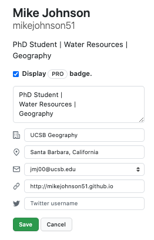

## **Submission**

- Be sure to render your entire site with `rmarkown::render_site()`
- Make sure that all of your labs are finalized and knit.
- Push both repos to GitHub.
- **Double** and **triple** check that your links work, if they dont link out to the correct pages, I cannot grade them. When grading, I will *only* look at the links submitted meaning I wont try to track down the files on GitHub.
- Once you are happy, submit your personal websites URL to Gauchospace.

## **Rubric**

- **Modified About Me** (10)
- **Geography 13 Page** (30)
- **Lab Aesthetics** (25)
- **CV/Resume** (15)
- **Web Site Apperance** (10)
- **Complete GitHub profile** (10)

**Total:** 100 points (110 possible points)